# Projekt z analizy dany

# Klastrowanie

```
Call:
stats::hclust(d = x, method = hc_method)

Cluster method   : ward.D2
Distance         : euclidean
Number of objects: 31
```

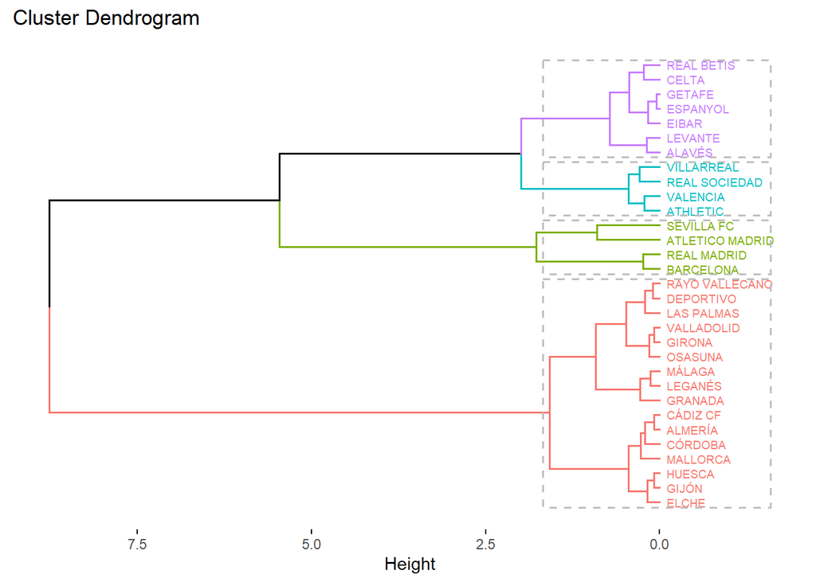

Nasze klastry są podzielone ze względu na wygrane drużyn i oznaczają:

- zielony - drużyny które najczęściej wygrywają w La Liga i kończą w czwórce najlepszych drużyn sezonu. Są uważane za najlepsze drużyny w kraju
- niebieski - drużyny które raz na jakiś czas mają lepszy okres i wskakują za którąś z drużyn z Top 4. Są uważane za dobre i solidne drużyny
- fioletowy - drużyny które utrzymują się w najlepszej klasie rozgrywkowej w Hiszpanii, ale nie stanowią znaczącej siły w lidze.
- czerwono - drużyny które są zazwyczaj w najniższych lokatach w lidze lub spadają z ligi do drugiej najlepszej klasy rozgrywkowej w Hiszpanii

# Podsumowanie

Zanim przeszliśmy do dopasowania modeli, wykonaliśmy eksploracyjną analizę danych, polegającą przede wszystkim na graficznej analizie zależności między zmiennymi. Dodatkowo opisaliśmy podstawowe statystyki analizowanych zmiennych.

Stworzyliśmy dwie macierzy korelacji które badały zależności miedzy zmiennymi oraz zbudowaliśmy dwa modele z których wybraliśmy jeden najbardziej dopasowany. Następnie na jego podstawie przetestowaliśmy KRML. Na koniec wykonaliśmy analizę skupień na podstawie wygranych danej drużyny.